# Assignement_4

Tejas Patil

2020 M04 21

#### **Executive Summary**:

##### **Problem Statement:**

##### Disease dataset provides the information of people and their physical and habitual attributes that can be helpful in predicting if that person will suffer from a particular type of disease or not. The aim of this project is to build the data analytical models that will help in predicting a person as disease prone or disease safe.

##### **1. Data Load and Cleanup:**

##### This section deals with cleaning the data. We’ll check the data for missing values, outliers etc. and treat those observations with suitable values. The data will also be checked for presence of any duplicate values. It also includes the statistically analysing the data.

##### **2. EDA and Feature selection:**

##### This section involves a deeper understanding of the data using tabular and visual representation of the data and **creating new columns** (tranforming data into a useful form). We’ll use **logistic regression** for the feature selection. Note that we are using logistic regression here because this a binary classification problem and logistic regression can provide good variable importance.

##### **3.Model building and evaluation:**

##### In this section, we will buil 6 different classification models namely: K-Nearest neighbors, Naive Bayes classifier, Random Forest, Supply vector machine linear and non linear, and finally Gradient boosting machine model. Models will be evaluated based on suitable evaluation parameters **(Accuracy and Recall)**. At last, we will use these models for predictions on test dataset.

### **1. Data load and Cleanup**

##### Importing the necessary libraries

```r
library(ggplot2)
library(gridExtra)
library(caret)
#library(mlbench)
#library(MLmetrics)
library(fastDummies)
#library(data.table)
library(corrplot)
library(pROC)
#library(klaR)
library(kernlab)
library(gbm)
library(glmnet)
library(e1071)
library(tidyverse)
library(keras)
library(yardstick)
library(rsample)
library(recipes)
library(hrbrthemes)
library(viridis)
library(C50)
library(rpart)

setwd('C:/Users/hp/Desktop/IST 707/Assignments/Assignment 4')
#getwd()
```

##### Importing the csv file into R enviornment and checking the structure and statistical summary of the dataset

##### Some early observations from the data:

##### AGE: minimum age is 29 years and maximum is 64 years. Hence our population for this problem is mainly adult people and people in early stages of old age

##### GENDER: training data is pretty imbalanced with respect to the gender variable. Females are almost twice that of male population.

##### Smoke, Alcohol and Excercise are classified as 1 and 0. The variable importance of these variables is doubtful as some people might be doing one of these things in small/large quantity relative to the other quantity.

```r
train_df <- read.csv('Disease Prediction Training.csv', stringsAsFactors = T)
#summary(train_df)
#str(train_df)
```

##### Checked the data for Missing values. The results returned shows us that there are **no missing values** in the data

```r
apply(is.na(train_df),2,sum)
```

```
##                 Age              Gender              Height              Weight High.Blood.Pressure
##                   0                   0                   0                   0                   0
##  Low.Blood.Pressure         Cholesterol             Glucose               Smoke             Alcohol
##                   0                   0                   0                   0                   0
##            Exercise             Disease
##                   0                   0
```

##### Checked the data for duplicate observations. The results returned shows us that there were **1752 duplicate observations** in the data. So, we have selected only the unique values

```r
nrow(train_df) - nrow(unique(train_df))
```

```
## [1] 1752
```

```r
train_un <- unique(train_df)
```

### **2. Exploratory Data Analysis**

#### **Analysing the target variable**

##### We find that target variable is of binary type and has 2 levels in it. So, this will be a binary classification problem. Here most important observation is that our target variable is balanced

```r
str(train_un$Disease)
```

```
##  int [1:47248] 0 1 0 0 0 0 1 0 1 0 ...
```

```r
table(train_un$Disease)
```

```
##
##     0     1
## 23172 24076
```

##### For the further EDA, we create 2 new dataframes containing only categorical and only numerical attributes respectively. Before that we convert all binary integer variables to factor for the easying the analysis process

```r
train_un$Smoke <- as.factor(train_un$Smoke)
train_un$Alcohol <- as.factor(train_un$Alcohol)
train_un$Exercise <- as.factor(train_un$Exercise)
train_un$Disease <- as.factor(train_un$Disease)


cat_df <- train_un[sapply(train_un, is.character) | sapply(train_un, is.factor)]
num_df <- train_un[sapply(train_un, is.numeric) | sapply(train_un, is.integer)]
```

##### Creating a function to generate bar plot for all the categorical variables and then using the grid plot to display all the visualization.

##### Impotant observations here are that most of the people do not smoke or drink and do excercise regularly. Ideally, the disease variable should have more ’0’s than ’1’s which questions the variable impotance for these three variables.

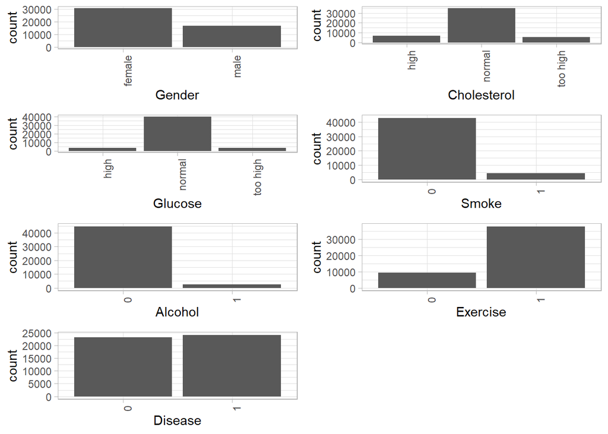

```r
bar_plot <- function(data_in, i) {
  data <- data.frame(x=data_in[[i]])
  p <- ggplot(data=data, aes(x=factor(x))) + stat_count() + xlab(colnames(data_in)[i]) + theme_light() +
    theme(axis.text.x = element_text(angle = 90, hjust =1))
  return (p)
}
mygrid1 <- list()
for (i in 1:length(cat_df)){
  myplot1 <- bar_plot(cat_df, i)
  mygrid1 <- c(mygrid1, list(myplot1))
}
do.call("grid.arrange", c(mygrid1, ncol=2))
```

##### Again creating a function, this time to generate a grid plot for displaying boxplots for all the numerical variables. We see that there are considerable **outliers** in variables named ‘Height’, ‘Weight’, ‘High.Blood.Pressure’ and ‘Low.Blood.Pressure’.

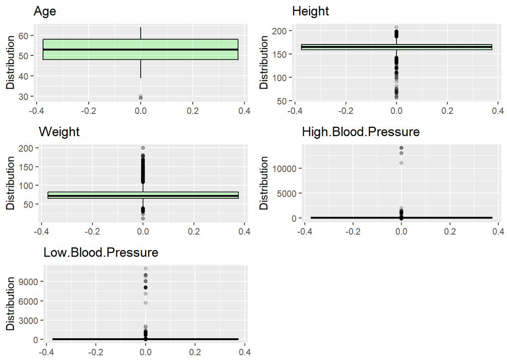

```r
box_plot <- function(data_in, i) {
  p <- ggplot(data_in, aes(y = data_in[,i])) + geom_boxplot(color="black", fill="green", alpha=0.2) + ggtitle(colnames(data_in)[i]) + ylab("Distribution") + theme(legend.position="none")
  return (p)
}

mygrid2 <- list()
for (i in 1:length(num_df)){
  myplot2 <- box_plot(num_df, i)
  mygrid2 <- c(mygrid2, list(myplot2))
}
do.call("grid.arrange", c(mygrid2, ncol=2))
```

##### Now let us check the range of these outliters. We create a new dataframe and check the values for extreme percentile values from both the ends for variables containing outliers

```r
quantiles <- c(0.0, 0.001, 0.002, 0.003, 0.01, 0.985, 0.99, 0.997, 0.998, 0.999, 1)
out_df <- data.frame(row.names = quantiles)
for (i in 1:length(num_df)){
  q <- as.vector(quantile(num_df[,i], quantiles))
  out_df[,i] <- q
}
colnames(out_df) <- colnames(num_df)
out_df <- t(out_df) #taking the transpose
print(out_df)
```

```
##                        0   0.001 0.002 0.003 0.01 0.985 0.99 0.997 0.998 0.999     1
## Age                   29  39.000    39    39   39    64   64    64    64    64    64
## Height                55 120.000   137   140  147   182  184   187   189   190   207
## Weight                10  40.000    41    43   48   113  117   130   135   150   200
## High.Blood.Pressure -150  12.000    13    70   90   180  180   200   200   220 14020
## Low.Blood.Pressure     0  41.235    53    60   60   130 1000  1100  1100  1110 11000
```

##### Creating a function to treat outliers by winsorizing to specific boundaries and using it to treat all numerical variables (except age) to treat outliers

```r
Out_Treat_W = function(x, lb, ub){
  LC = quantile(x, lb)
  UC = quantile(x, ub)
  UOut <- which(x > UC)
  LOut <- which(x < LC)
  for (i in 1:length(UOut)){
    x[UOut[i]] <- UC
  }
  for (i in 1:length(LOut)){
    x[LOut[i]] <- LC
  }
  return(x)
}
train_un$Height <- Out_Treat_W(train_un$Height, 0.001, 1)
train_un$Weight <- Out_Treat_W(train_un$Weight, 0.001, 1)
train_un$Low.Blood.Pressure <- Out_Treat_W(train_un$Low.Blood.Pressure, 0.001, 0.985)
train_un$High.Blood.Pressure <- Out_Treat_W(train_un$High.Blood.Pressure, 0.003, 0.999)
```

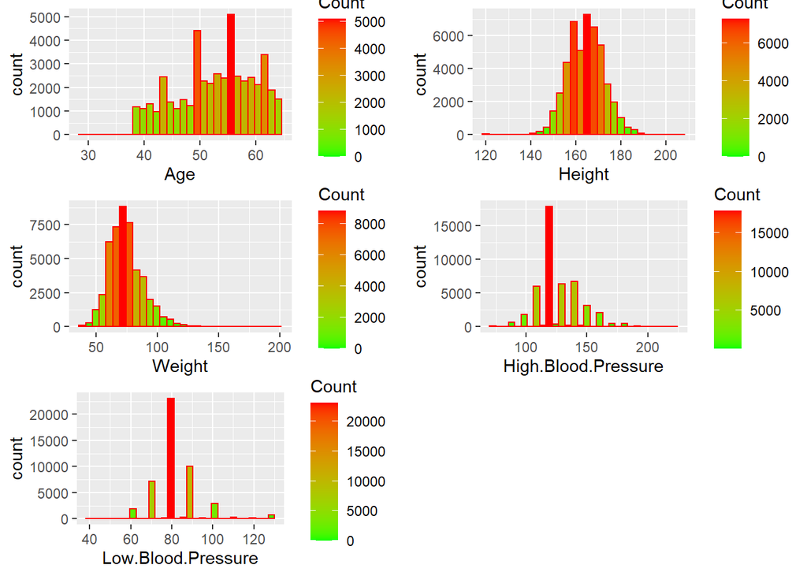

```r
num_df <- train_un[sapply(train_un, is.numeric) | sapply(train_un, is.integer)]

hist_plot <- function(data_in, i) {
  data <- data.frame(x=data_in[[i]])
  p <- ggplot(data=data, aes(data[,1])) +
    geom_histogram(bins = 30, col="red", aes(fill=..count..)) +
    xlab(colnames(data_in)[i]) +
    scale_fill_gradient("Count", low="green", high="red")
  return (p)
}
mygrid2 <- list()
for (i in 1:length(num_df)){
  myplot2 <- hist_plot(num_df, i)
  mygrid2 <- c(mygrid2, list(myplot2))
}
do.call("grid.arrange", c(mygrid2, ncol=2))
```

##### Plotting the correlation matrix to check for the multicollinearity between numeric independent variables. Only significant correlation is between **Low blood pressure** and **High blod pressure** variables.

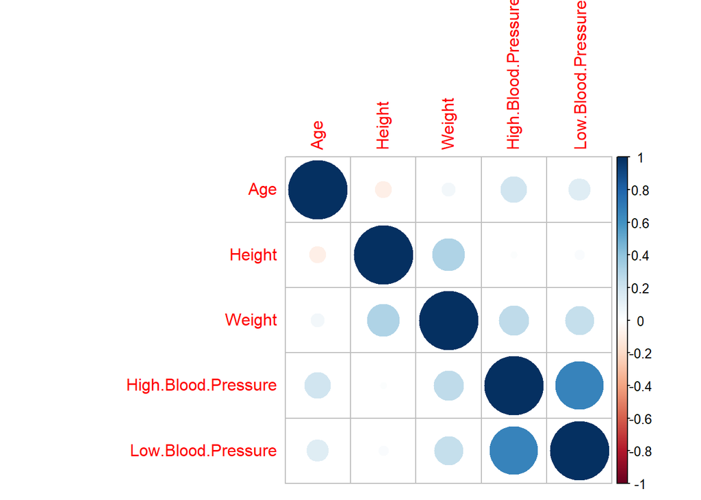

```r
corMatrix <- cor(num_df)
#View(descrCor)
#print(descrCor)
corrplot(corMatrix)
```

## Bivariate Analysis

##### Making a function to plot boxplots for bivariate analysis

```r
bivariate_plot <- function(num_var, title){
  plt <- train_un %>% ggplot( aes(x=Disease, y=num_var, fill=Disease)) + geom_boxplot() +
    scale_fill_viridis(discrete = T, alpha=0.5) +
    theme(legend.position="none", plot.title = element_text(size=11)) +
    ggtitle(title) + xlab("")
  return(plt)
}
```

##### Low Blood Pressure vs Disease: This graph tells us that on an average low blood pressure was higher for the people wtih disease, which logically makes sense if the disease is related to heart.

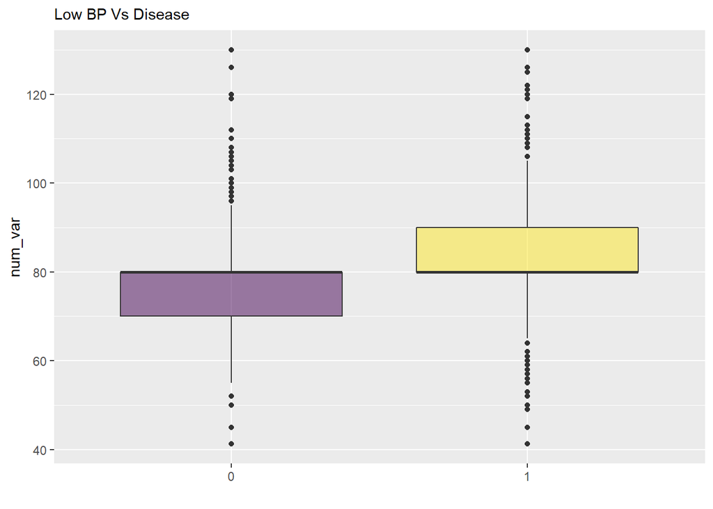

```r
bivariate_plot(train_un$Low.Blood.Pressure, "Low BP Vs Disease")
```

##### High Blood Pressure vs Disease: Similar to Low BP, even high blood pressure has higher average values for people with disease rather than people that do not have the disease.

[figure not shown]

```r
bivariate_plot(train_un$High.Blood.Pressure, "Weight Vs Disease")
```

#### Creating new variables:

##### We have two variables that measure the blood pressure (High and Low). Now, we will create a single categorical variable that will try to capture the combined effect of both variables on a person’s health. We will the classifiy the health and unhealthy blood pressure ranges into 5 different categories namely: **Normal**, **Elevated** (Slight increase), **Hypertension (Stage 1)**, **Hypertension (Stage 2)** and **Hypertensive Crisis** (Critical condition). These ranges are obtained using the domain knowledge from the website:

##### [https://www.heart.org/en/health-topics/high-blood-pressure/understanding-blood-pressure-readings]

##### Checking if the variable can make a impact on our model

```r
for (i in 1:nrow(train_un)) {
  if (train_un$High.Blood.Pressure[i] >= 180 | train_un$Low.Blood.Pressure[i] >= 120) {
    train_un$BP_Category[i] = "Hypertensive"
  }
  else if (train_un$High.Blood.Pressure[i] >= 140 | train_un$Low.Blood.Pressure[i] >= 90) {
    train_un$BP_Category[i] = "HT_stage2"
  }
  else if (train_un$High.Blood.Pressure[i] >= 130 | train_un$Low.Blood.Pressure[i] >= 80) {
    train_un$BP_Category[i] = "HT_stage1"
  }
  else if (train_un$High.Blood.Pressure[i] >= 120 & train_un$Low.Blood.Pressure[i] < 80) {
    train_un$BP_Category[i] = "Elevated"
  }
  else {
    train_un$BP_Category[i] = "Normal"
  }
}
train_un$BP_Category <- as.factor(train_un$BP_Category)
table(train_un$Disease, train_un$BP_Category)
```

```
##
##     Elevated HT_stage1 HT_stage2 Hypertensive Normal
##   0     1431     12790      3516          237   5198
##   1      714      8406     12308         1199   1449
```

##### Now we’ll be creating two more new variable called BMI (Body Mass Index). BMI is a measure of body fat considering height and weight of a person, it applies to adult men and women. The second variable is nothing but the categorization of the BMI variable.

```r
for (i in 1:nrow(train_un)) {
  train_un$BMI[i] <- (train_un$Weight[i] / ((train_un$Height[i]/100)**2))
  if (train_un$BMI[i] <= 18) {
    train_un$BMI_CAT[i] = "Underweight"
  }
  else if (train_un$BMI[i] <= 24) {
    train_un$BMI_CAT[i] = "Healthy"
  }
  else if (train_un$BMI[i] <= 29) {
    train_un$BMI_CAT[i] = "Overweight"
  }
  else {
   train_un$BMI_CAT[i] = "Obese"
  }
}
train_un$BMI_CAT <- as.factor(train_un$BMI_CAT)
```

##### Of all the models we’ll be using, few are distance based algorithms. Hence, it is very necessary to scale the numerical variables in our data. We have tried here 2 types of scaling: **normalization and standardization**. After running the models for both the scaling, standard scale was finally chosen for the data.

```r
train_sc <- train_un

for(i in 1:length(colnames(train_sc))){
  if(class(train_sc[,i]) == "numeric" || class(train_sc[,i]) == "integer"){
    train_sc[,i] <- as.vector(scale(train_sc[,i], center = T))
  }
}

##the normalization function is created
#norm_ZN <- function(x){
#  y <- c()
#  for (i in 1:length(x)){
#    y <- c(y, ((x[i]) - min(x))/(max(x) - min(x)))
#  }
#  return(y)
#}
#for(i in 1:length(train_sc)){
#  if(class(train_sc[,i]) == "numeric" || class(train_sc[,i]) == "integer"){
#    train_sc[,i] <- norm_ZN(train_sc[,i])
#  }
#}
```

##### Now, we’ll be creating the **dummy variables** for all the categorical variables our data. After we are done with that we need to drop the original categorical variables.

```r
dummies <- c('Gender','Cholesterol','Glucose', 'BP_Category', 'BMI_CAT')
train_dm <- dummy_cols(train_sc, select_columns = dummies)
train_dm <- train_dm[,-which(names(train_dm) %in% dummies)]
#str(train_dm)
#View(train_dm)
```

```r
i <- sapply(train_dm, is.integer)
train_dm[i] <- lapply(train_dm[i], as.factor)
```

##### Since this is a binary classification problem, we can use **logistic regression** model to check the importance of the variables. This will give us confidence in our newly created variables and eliminate the variables that are not significant.

```r
summary(glm(Disease ~. , data=train_dm, family=binomial))
```

```
##
## Call:
## glm(formula = Disease ~ ., family = binomial, data = train_dm)
##
## Deviance Residuals:
##     Min       1Q   Median       3Q      Max
## -3.4150  -0.8978   0.3106   0.8726   2.4388
##
## Coefficients: (5 not defined because of singularities)
##                           Estimate Std. Error z value Pr(>|z|)
## (Intercept)                0.40379    0.16444   2.455 0.014070 *
## Age                        0.35493    0.01113  31.879  < 2e-16 ***
## Height                     0.02253    0.04954   0.455 0.649188
## Weight                     0.06988    0.09207   0.759 0.447841
## High.Blood.Pressure        0.61697    0.02147  28.738  < 2e-16 ***
## Low.Blood.Pressure         0.04708    0.02499   1.884 0.059513 .
## Smoke1                    -0.15403    0.04145  -3.716 0.000203 ***
## Alcohol1                  -0.20829    0.04999  -4.167 3.09e-05 ***
## Exercise1                 -0.20401    0.02642  -7.722 1.15e-14 ***
## BMI                        0.07089    0.08663   0.818 0.413180
## Gender_female1             0.03405    0.02691   1.265 0.205798
## Gender_male1                    NA         NA      NA       NA
## Cholesterol_high1         -0.68233    0.05015 -13.605  < 2e-16 ***
## Cholesterol_normal1       -1.05398    0.04271 -24.676  < 2e-16 ***
## `Cholesterol_too high`1         NA         NA      NA       NA
## Glucose_high1              0.31353    0.06105   5.135 2.82e-07 ***
## Glucose_normal1            0.32078    0.04711   6.809 9.84e-12 ***
## `Glucose_too high`1             NA         NA      NA       NA
## BP_Category_Elevated1     -0.04217    0.05886  -0.716 0.473694
## BP_Category_HT_stage11     0.10166    0.04691   2.167 0.030223 *
## BP_Category_HT_stage21     0.91849    0.07376  12.452  < 2e-16 ***
## BP_Category_Hypertensive1  0.51599    0.15853   3.255 0.001134 **
## BP_Category_Normal1             NA         NA      NA       NA
## BMI_CAT_Healthy1           0.02390    0.14420   0.166 0.868340
## BMI_CAT_Obese1             0.06558    0.15840   0.414 0.678891
## BMI_CAT_Overweight1        0.11940    0.14747   0.810 0.418156
## BMI_CAT_Underweight1            NA         NA      NA       NA
## ---
## Signif. codes:  0 '***' 0.001 '**' 0.01 '*' 0.05 '.' 0.1 ' ' 1
##
## (Dispersion parameter for binomial family taken to be 1)
##
##     Null deviance: 65482  on 47247  degrees of freedom
## Residual deviance: 52467  on 47226  degrees of freedom
## AIC: 52511
##
## Number of Fisher Scoring iterations: 4
```

```r
lr_drop <- c('Height', 'Weight', 'BMI_CAT_Healthy', 'BMI_CAT_Obese', 'BMI_CAT_Overweight', 'BMI_CAT_Underweight')
train_dm <- train_dm[,-which(names(train_dm) %in% lr_drop)]

for (i in 1:nrow(train_dm)) {
  if (train_dm$BP_Category_Elevated[i] == "1") {
    train_dm$BP_Category_Normal[i] = "1"
  }
  else {
    train_dm$BP_Category_Normal[i] = train_dm$BP_Category_Normal[i]
  }
}
train_dm$BP_Category_Elevated <- NULL
train_dm_saved <- train_dm
#str(train_dm)
```

##### Splitting the traing data into two parts, training and validation datasets. Here we are using **75-25** split.

```r
set.seed(73)
train_index <- createDataPartition(train_dm$Disease, p = 0.75, list = FALSE)

train_dm_train <- train_dm[train_index, ]
train_dm_validate <- train_dm[-train_index, ]
```

### **3. Model building and Evaluation**

### **Base Model:**

##### First Applying the base model (without any hyperparameters) to the training dataset. We observe that our Accuracy is close to **72.6%** on the base model.

#### **Summary Interpretation:**

##### It looks like most of our variables are significant except **Gender** and **Low Blood Pressure**. We know from correlation plot that Low blood pressure has a very **high correlation** with High blood pressure. Hence, in regression automatically one of the two variables becomes less significant. The significant variables have the **p-value less than 0.05**. We call them significant because we can say that we are **95%** confident that the coefficient of those variables lie within the **confidence interval**. Unfortunately, the summary of logistic regression does not show us the confidence interval’s lower and upper limit. Also, we can see that coefficient of all the variables are low, that is because we are performing regression on the **scaled data**.

```r
summary(glm_base)
```

```
##
## Call:
## NULL
##
## Deviance Residuals:
##     Min       1Q   Median       3Q      Max
## -3.0250  -0.8952   0.3025   0.8679   2.4162
##
## Coefficients: (4 not defined because of singularities)
##                               Estimate Std. Error z value Pr(>|z|)
## (Intercept)                    0.44930    0.07786   5.771 7.90e-09 ***
## Age                            0.35700    0.01285  27.783  < 2e-16 ***
## High.Blood.Pressure            0.61622    0.02377  25.927  < 2e-16 ***
## Low.Blood.Pressure             0.02236    0.02916   0.767  0.44330
## Smoke1                        -0.15440    0.04756  -3.246  0.00117 **
## Alcohol1                      -0.22594    0.05785  -3.905 9.41e-05 ***
## Exercise1                     -0.19221    0.03059  -6.283 3.32e-10 ***
## BMI                            0.13621    0.01346  10.123  < 2e-16 ***
## Gender_female1                -0.03058    0.02753  -1.111  0.26670
## Gender_male1                        NA         NA      NA       NA
## Cholesterol_high1             -0.73111    0.05783 -12.643  < 2e-16 ***
## Cholesterol_normal1           -1.09452    0.04942 -22.149  < 2e-16 ***
## `\\`Cholesterol_too high\\`1`       NA         NA      NA       NA
## Glucose_high1                  0.35596    0.07061   5.041 4.63e-07 ***
## Glucose_normal1                0.36749    0.05441   6.755 1.43e-11 ***
## `\\`Glucose_too high\\`1`           NA         NA      NA       NA
## BP_Category_HT_stage11         0.15216    0.04745   3.207  0.00134 **
## BP_Category_HT_stage21         0.99769    0.07782  12.821  < 2e-16 ***
## BP_Category_Hypertensive1      0.73177    0.17909   4.086 4.39e-05 ***
## BP_Category_Normal1                 NA         NA      NA       NA
## ---
## Signif. codes:  0 '***' 0.001 '**' 0.01 '*' 0.05 '.' 0.1 ' ' 1
##
## (Dispersion parameter for binomial family taken to be 1)
##
##     Null deviance: 49112  on 35435  degrees of freedom
## Residual deviance: 39252  on 35420  degrees of freedom
## AIC: 39284
##
## Number of Fisher Scoring iterations: 4
```

##### **Performance Evaluation Parameters:** For this problem statement, when we have to predict if the patient is suffering from the disease or not, it very important to reduce the type 2 error. For that we have the optimize the **recall** value. Also, since the dataset is balanced, **accuracy** is the best evaluation parameter.

##### **Predictions:** Now predicting the values on validation dataset using the base model.

```r
glm_predict <- predict(glm_base, newdata = train_dm_validate)
confusionMatrix(glm_predict, train_dm_validate$Disease, positive = "1")
```

```
## Confusion Matrix and Statistics
##
##           Reference
## Prediction    0    1
##          0 4552 1993
##          1 1241 4026
##
##                Accuracy : 0.7262
##                  95% CI : (0.7181, 0.7342)
##     No Information Rate : 0.5096
##     P-Value [Acc > NIR] : < 2.2e-16
##
##                   Kappa : 0.4536
##
##  Mcnemar's Test P-Value : < 2.2e-16
##
##             Sensitivity : 0.6689
##             Specificity : 0.7858
##          Pos Pred Value : 0.7644
##          Neg Pred Value : 0.6955
##              Prevalence : 0.5096
##          Detection Rate : 0.3408
##    Detection Prevalence : 0.4459
##       Balanced Accuracy : 0.7273
##
##        'Positive' Class : 1
##
```

### **Logistic Regression Regularised model:**

##### **Regularization Strategy:** We need to regularise the logistic regression. Unfortunately, with only caret package we cannot define the regularisation parameters. So, we have to use **glmnet package** and define method glmnet in train function of caret package. We will be able to tune two hyperparameters for regularization:

##### **Hyperparameters:**

##### 1] **lambda**: This paramater controls the **instensity** of regularization. It means that a penalty term is added to **cost function** in logistic regression. This added penalty tern helps in reducing the coefficients of less important variables, so that they will not affect the predictions by much.

##### 2] **alpha:** alpha acts as a **slider between L1 and L2** regularization. L1 regularization can make the coefficients of variables **completely 0**, hence making them dead variables. L2 regularization also reduces the coefficients but cannot make it completely 0.

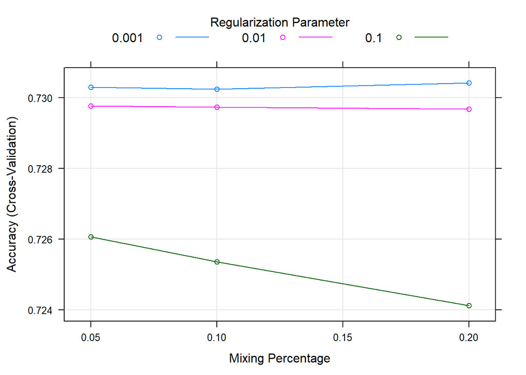

```r
glmGrid <-  expand.grid(alpha = c(0.05,0.1,0.2), lambda = c(0.001,0.01, 0.1))

glmnet_reg = train(Disease ~ ., data = train_dm_train, method = "glmnet", trControl =
                     trainControl(method = "cv", number = 3), tuneGrid = glmGrid, metric =
                     "Accuracy")
#glmnet_reg
plot(glmnet_reg)
```

#### **Strategy for Regularization:**

##### Printing the hyperparameter values for best model

```r
get_best_result = function(caret_fit) {
  best = which(rownames(caret_fit$results) == rownames(caret_fit$bestTune))
  best_result = caret_fit$results[best, ]
  rownames(best_result) = NULL
  best_result
}
get_best_result(glmnet_reg)
```

```
##   alpha lambda  Accuracy     Kappa  AccuracySD     KappaSD
## 1   0.2  0.001 0.7304154 0.4618766 0.003909346 0.007696668
```

##### **Predictions:** Now, predicting the values on validation data using the regularized model. One thing that we observe is that our accuracy does not increase by much. Hence, we can conclude that the base model was **not overfitted** on training data.

```r
glmnet_reg_predict <- predict(glmnet_reg, newdata = train_dm_validate)
confusionMatrix(glmnet_reg_predict, train_dm_validate$Disease, positive = "1")
```

```
## Confusion Matrix and Statistics
##
##           Reference
## Prediction    0    1
##          0 4554 1998
##          1 1239 4021
##
##                Accuracy : 0.726
##                  95% CI : (0.7178, 0.734)
##     No Information Rate : 0.5096
##     P-Value [Acc > NIR] : < 2.2e-16
##
##                   Kappa : 0.4531
##
##  Mcnemar's Test P-Value : < 2.2e-16
##
##             Sensitivity : 0.6681
##             Specificity : 0.7861
##          Pos Pred Value : 0.7644
##          Neg Pred Value : 0.6951
##              Prevalence : 0.5096
##          Detection Rate : 0.3404
##    Detection Prevalence : 0.4453
##       Balanced Accuracy : 0.7271
##
##        'Positive' Class : 1
##
```

##### **ROC and AUC:**

##### Plotting the roc curve and calculating the area under that curve. First, creating for it and using the same function for the next models.

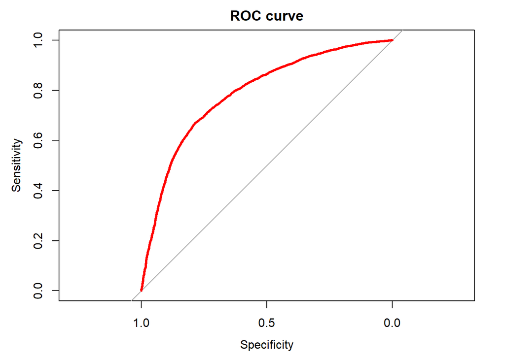

```
## [[1]]
##
## Call:
## roc.default(response = true_val, predictor = probs)
##
## Data: probs in 5793 controls (true_val 0) < 6019 cases (true_val 1).
## Area under the curve: 0.7879
##
## [[2]]
## Area under the curve: 0.7879
```

```r
ROC_AUC <- function(true_val, probs){
  roc_curve=roc(response=true_val, predictor= probs)
  fig <- plot(roc_curve, col="red", lwd=3, main="ROC curve")
  score <- auc(roc_curve)
  ro_au <- list(fig, score)
  return(ro_au)
}
glmnet_probs <- predict(glmnet_reg, newdata = train_dm_validate, type = 'prob')
ROC_AUC(train_dm_validate$Disease, glmnet_probs$`1`)
```

### Deep Learning: Artificial Neural Networks

##### **Data Pre-Processing:**

##### Transforming the data for neural networks. Converting all the factor dummy variables to __integer data typ__e. Trying the **‘receipe’** library preprocessing the data. Since, our data is already pre-processed and cleaned we do not need to do much. ##### Splitting the data training and validation to check for the overfitting of the deep learning models.

```r
train_dm_saved <- train_dm
i <- sapply(train_dm_saved, is.factor)
train_dm_saved[i] <- lapply(train_dm_saved[i], as.character)

i <- sapply(train_dm_saved, is.character)
train_dm_saved[i] <- lapply(train_dm_saved[i], as.integer)


train_dm_tbl <- train_dm_saved %>% drop_na()

set.seed(100)
train_test_split <- initial_split(train_dm_tbl, prop = 0.75)
train_tbl <- training(train_test_split)
validate_tbl <- testing(train_test_split)

rec_obj <- recipe(Disease ~ ., data = train_tbl) %>% prep(data = train_tbl)

train_x <- bake(rec_obj, new_data = train_tbl) #%>% select(-Disease)
validate_x <- bake(rec_obj, new_data = validate_tbl) #%>% select(-Disease)
train_y <- ifelse(pull(train_tbl, Disease) == "1", 1, 0)
validate_y <- ifelse(pull(validate_tbl, Disease) == "1", 1, 0)

train_x <- train_x[, -which(colnames(train_x) == "Disease")]
validate_x <- validate_x[, -which(colnames(validate_x) == "Disease")]
```

### **ANN: 0 Hidden Layers**

##### **Model Description:**

##### Aritificial neural network with 0 hidden layers is same as a **perceptron model**. There will be a input layer and a output layer. Input layer is nothing but the training example, so we do not need to specify it. But, in this case the activation function is **sigmoid function** instead of the sign function. The **linear combination** of input values and weights of the links is processed through and converted to required format by activation function.

##### **Strategy:** Since, grid search is not possible in keras, we will be using nested for loops for tuning the hyperparamters.

##### **Hyperparameters:**

##### 1] epochs: Number of epochs is the numer of times that whole dataset has completed a forward and backward journey through the network.

##### 2] batch size: It is not possible to send whole data at once through the network, hence we create small batches of training examples. Number of example in any batch is known as batch size.

##### **Nodes and Layers:**

##### In the input layer we will have nodes = number of variables and in the output node there will be only one node since, it is a binary classification problem. For a multiple class classification, nodes in output function = number of classes.

##### **Activation Function:**

##### For output layer, it will be **Sigmoid Function**, because this is a binary classification problem and output of sigmoid function is probability between 0 and 1. We will use the threshold of 0.5 to classify as either 1 or 0.

##### **Regularization:**

##### It will not be performed for 0 hidden layers, but will be peformed for model with hidden layers.

##### **Optimzation:**

##### The process of changing the weights of connecting links is defined by optimizer. For example, **learning rate** parameter of gradient descent tells us by how much should we change the weights. Higher values take less time to run, but might _**overshoot the global/local minima** and hence it is very important to define right value for learning rate and finding the right optimizer. In this case, we are using **adam** as our optimization function. ##### **Loss Function:** We have to define a loss function that will calculate the difference between **actual value and predicted value**. That function will use this difference to **update the weights** of the connecting links. In this case, since it is a binary classification problem, we use **binary_crossentropy** loss function.

```r
batch_size_grid <- c(32,64,128)
epochs_grid <- c(80,100,120)

ann0_models <- list()
ann0_fits <- list()

p <- 1
for (i in 1:length(batch_size_grid)){
  for (j in 1:length(epochs_grid)){
   keras0_model <- keras_model_sequential()
    keras0_model %>%
      layer_dense(units = 1, kernel_initializer = "uniform", activation = "sigmoid") %>%
      compile(optimizer = "adam", loss = "binary_crossentropy", metrics = c("accuracy"))

    keras0_fit <- fit(object = keras0_model, x = as.matrix(train_x), y = train_y, batch_size =
                        batch_size_grid[i], epochs = epochs_grid[j], validation_split = 0.25,
                        verbose = F)
    ann0_models[[p]] <- keras0_model
    ann0_fits[[p]] <- keras0_fit
    p <- p + 1
  }
}
```

##### **Finding the Best Model:**

##### Now, after fine tuning the model with right hyperparameters, we need to extract the best model. For this we will use the **average of validation accuracy** of every model for all the epochs.

##### Important Observation: After running the multiple times for different hyperparameter values, we found that best batch_size stays constant, while best epochs number keeps on fluctuating between these 3 values.

```r
avg_acc <- c()
for (i in 1:length(ann0_models)){
  valacc <- ann0_fits[[i]]$metrics$val_accuracy
  avg_acc[i] <- sum(valacc)/length(valacc)
  best_model_Index <- which.max(avg_acc)
  keras0_best_model <- ann0_models[best_model_Index][[1]]
  keras0_best_fit <- ann0_fits[best_model_Index][[1]]
}
paste0("Batch Size for best model is: ", keras0_best_fit$params$batch_size)
```

```
## [1] "Batch Size for best model is: 32"
```

```r
paste0("No. Epochs for best model is: ", keras0_best_fit$params$epochs)
```

```
## [1] "No. Epochs for best model is: 80"
```

##### Plotting the fitted model over the training dataset. This plots gives us the comparison between training accuracy/loss and validation accuracy/loss. If the difference between training and validation accuracy is increasing that means the model is getting overfitted.

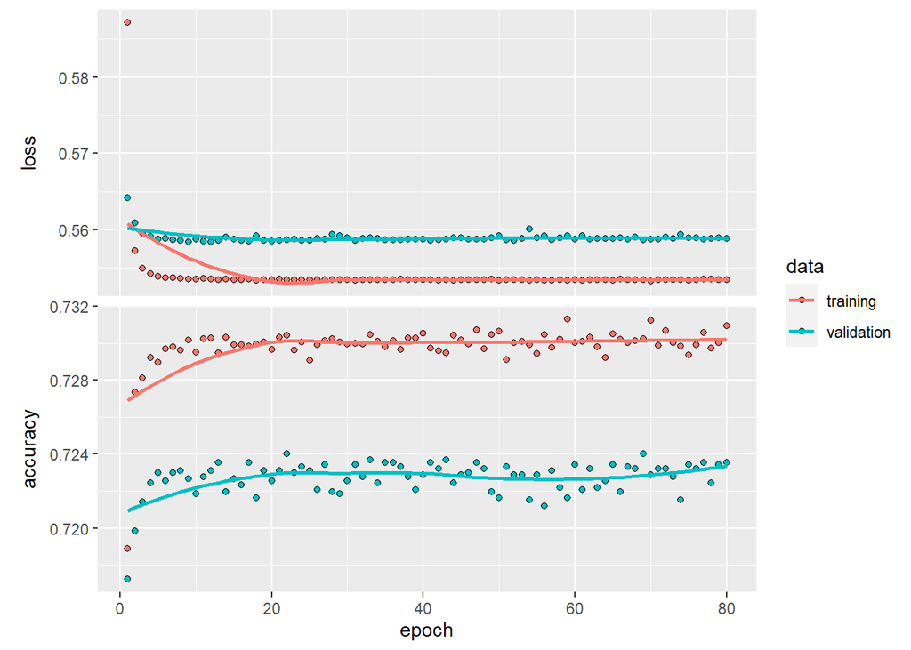

```r
plot(keras0_best_fit)
```

##### **Predictions:**

##### Now, making prediction on the validation data using the best model. Predicting the classes as well as the probabilities for the instances.

```r
pred_class_keras0 <- predict_classes(object = keras0_best_model, x = as.matrix(validate_x)) %>%
as.vector()
pred_prob_keras0 <- predict_proba(object = keras0_best_model, x = as.matrix(validate_x)) %>%
as.vector()
```

##### **Performance Evaluation Parameters:**

##### Plotting the confusion matrix and calculating **Accuracy, Recall and F1-Score**. We are calculating F1-Score because it is the harmonic mean of recall and precision, hence a balanced measure of both the quantities.

```r
estimates_keras0_tbl <- tibble(truth = as.factor(validate_y), estimate =
                                 as.factor(pred_class_keras0), class_prob = pred_prob_keras0)
options(yardstick.event_first = F)
estimates_keras0_tbl %>% conf_mat(truth, estimate)
```

```
##           Truth
## Prediction    0    1
##          0 4513 1969
##          1 1275 4055
```

```r
estimates_keras0_tbl %>% metrics(truth, estimate)
```

```
## # A tibble: 2 x 3
##   .metric  .estimator .estimate
##   <chr>    <chr>          <dbl>
## 1 accuracy binary         0.725
## 2 kap      binary         0.452
```

```r
estimates_keras0_tbl %>% recall(truth, estimate)
```

```
## # A tibble: 1 x 3
##   .metric .estimator .estimate
##   <chr>   <chr>          <dbl>
## 1 recall  binary         0.673
```

```r
estimates_keras0_tbl %>% f_meas(truth, estimate, beta = 1)
```

```
## # A tibble: 1 x 3
##   .metric .estimator .estimate
##   <chr>   <chr>          <dbl>
## 1 f_meas  binary         0.714
```

##### **ROC and AUC:**

##### Plotting the ROC curve and calculating the area under curve.

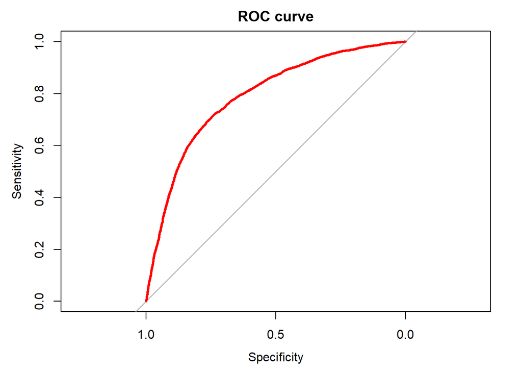

```
## [[1]]
##
## Call:
## roc.default(response = true_val, predictor = probs)
##
## Data: probs in 5788 controls (true_val 0) < 6024 cases (true_val 1).
## Area under the curve: 0.7894
##
## [[2]]
## Area under the curve: 0.7894
```

```r
ROC_AUC(validate_y, pred_prob_keras0)
```

### **Comparison between Linear SVM, Logistic Regression and Single Layer Perceptron:**

##### We will compare the accuracies of all three model on valisation dataset.

```r
#transforming svm prediction to match new changes
svm_predict_trans <- as.factor(as.integer(svm_lin_tuned_predict) - 1)

svmLin <- confusionMatrix(svm_predict_trans, train_dm_validate$Disease)$overall["Accuracy"]
logReg  <- confusionMatrix(glmnet_reg_predict, train_dm_validate$Disease)$overall["Accuracy"]
annZero <- (estimates_keras0_tbl %>% metrics(truth, estimate))$.estimate[1]

paste0("The validation accuracy for SVM_Linear: ", svmLin)
```

```
## [1] "The validation accuracy for SVM_Linear: 0.712580426684727"
```

```r
paste0("The validation accuracy for Logistic_R: ", logReg)
```

```
## [1] "The validation accuracy for Logistic_R: 0.725956654249915"
```

```r
paste0("The validation accuracy for ANN0_Layer: ", annZero)
```

```
## [1] "The validation accuracy for ANN0_Layer: 0.725364036572977"
```

##### **Theoretical Similarity:**

##### **Linear SVM:** This algorithm is maximum margin classifier. It uses a linear hyperplane to seperate two classes i.e. it creates a linear decision boundary. Linear SVM adds a layer of margin on either side of the decision boundary to reduce the generalization error.

##### **Logistic Regression:** Being a regression algorithm, logistic regression with multiple input variables, tries to fit a linear hyperplane such that the sum of squared error is minimum for the fitted hyperplane. Then it uses sigmoid function to map the output of linear combination of all variables and weights between 0 and 1. A threshold is set between 0 and 1 (generally 0.5), to sperate two classes.

##### **Perceptron 0 Hidden Layer:** Perceptron with 0 hidden layer linearly combines the weights and the corresponding input data values, passes it to the output layer. Output layer consists of an activation function, that generates the output in required form and uses a linear hyperplane to classify.

##### **Inference:** All the three methods use linear hyperplane for classification. The technique of fitting a hyperplane for logistic and Perceptron0 is very similar. But, linear SVM uses maximum margin technique to find the right inclination for linear boundary. Even then, the performance of all three models on same dataset are comparable.

### **ANN: One Hidden Layer**

##### **Loss Function:**

##### Loss function also remains the same: **binary_crossentropy**

```r
batch_size_grid <- c(32,64,128)
epochs_grid <- c(60,80,100)

ann1_models <- list()
ann1_fits <- list()

p <- 1
for (i in 1:length(batch_size_grid)){
  for (j in 1:length(epochs_grid)){
    keras1_model <- keras_model_sequential()
    keras1_model %>%
    layer_dense(units = 19, kernel_initializer = "uniform", activation = "relu", input_shape =
                  ncol(train_x)) %>%
    layer_dropout(rate = 0.1) %>%
    layer_dense(units = 1, kernel_initializer = "uniform", activation = "sigmoid") %>%
    compile(optimizer = "sgd", loss = "binary_crossentropy", metrics = c("accuracy"))

    keras1_fit <- fit(object = keras1_model, x = as.matrix(train_x), y = train_y, batch_size =
                        batch_size_grid[i], epochs = epochs_grid[j], validation_split = 0.25,
                      verbose = F)

    ann1_models[[p]] <- keras1_model
    ann1_fits[[p]] <- keras1_fit
    p <- p + 1
  }
}
```

##### **Finding the Best Model:**

##### Again using the **average validation accuracy** over all epochs as metric to select best model.

```r
avg_acc <- c()
for (i in 1:length(ann1_models)){
  valacc <- ann1_fits[[i]]$metrics$val_accuracy
  avg_acc[i] <- sum(valacc)/length(valacc)
  best_model_Index <- which.max(avg_acc)
 keras1_best_model <- ann1_models[best_model_Index][[1]]
  keras1_best_fit <- ann1_fits[best_model_Index][[1]]
}
paste0("Batch Size for best model is: ", keras1_best_fit$params$batch_size)
```

```
## [1] "Batch Size for best model is: 32"
```

```r
paste0("No. Epochs for best model is: ", keras1_best_fit$params$epochs)
```

```
## [1] "No. Epochs for best model is: 80"
```

##### Plotting the fitted model over the training dataset. This plots gives us the comparison between training accuracy/loss and validation accuracy/loss. If the difference between training and validation accuracy is increasing that means the model is getting overfitted.

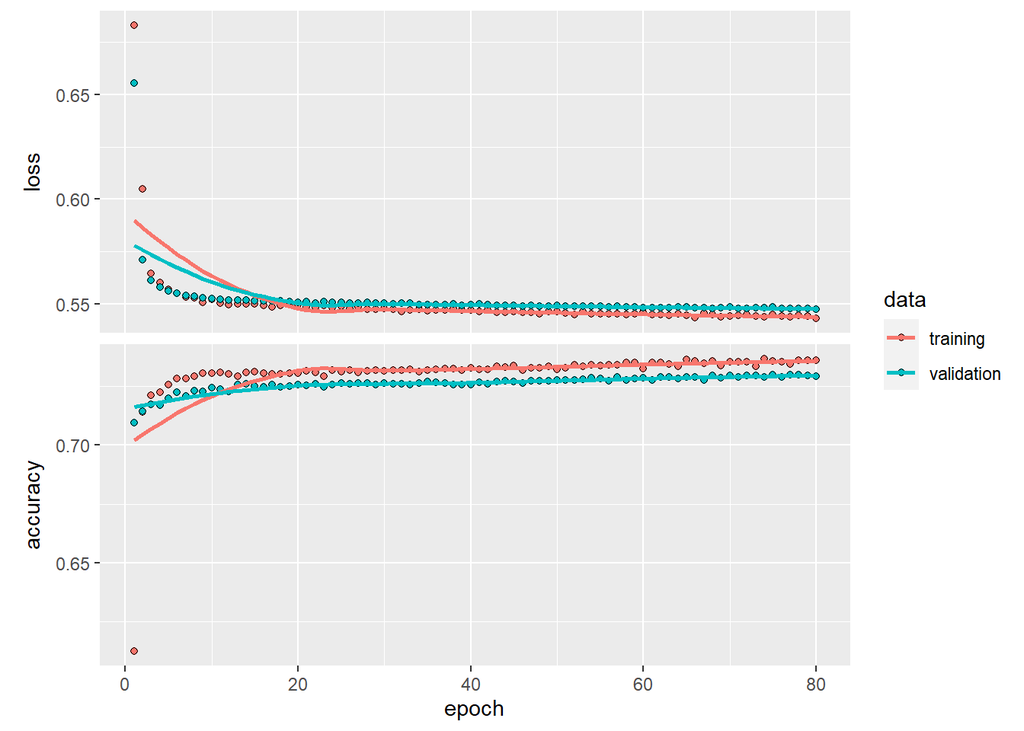

```r
plot(keras1_best_fit)
```

##### **Predictions:**

##### Now, making prediction on the validation data using the best model. Predicting the classes as well as the probabilities for the instances.

```r
pred_class_keras1 <- predict_classes(object = keras1_best_model, x = as.matrix(validate_x)) %>%
as.vector()
pred_prob_keras1 <- predict_proba(object = keras1_best_model, x = as.matrix(validate_x)) %>%
as.vector()
```

##### **Performance Evaluation Parameters:**

##### Plotting the confusion matrix and calculating **Accuracy, Recall and F1-Score**. Again, F1-Score gives a balanced measure of recall and precision.

```r
estimates_keras1_tbl <- tibble(truth = as.factor(validate_y), estimate =
                                 as.factor(pred_class_keras1), class_prob = pred_prob_keras1)
options(yardstick.event_first = F)
estimates_keras1_tbl %>% conf_mat(truth, estimate)
```

```
##           Truth
## Prediction    0    1
##          0 4386 1770
##          1 1402 4254
```

```r
estimates_keras1_tbl %>% metrics(truth, estimate)
```

```
## # A tibble: 2 x 3
##   .metric  .estimator .estimate
##   <chr>    <chr>          <dbl>
## 1 accuracy binary         0.731
## 2 kap      binary         0.463
```

```r
estimates_keras1_tbl %>% recall(truth, estimate)
```

```
## # A tibble: 1 x 3
##   .metric .estimator .estimate
##   <chr>   <chr>          <dbl>
## 1 recall  binary         0.706
```

```r
estimates_keras1_tbl %>% f_meas(truth, estimate, beta = 1)
```

```
## # A tibble: 1 x 3
##   .metric .estimator .estimate
##   <chr>   <chr>          <dbl>
## 1 f_meas  binary         0.728
```

##### **ROC and AUC:**

##### Plotting the ROC curve and calculating the area under curve.

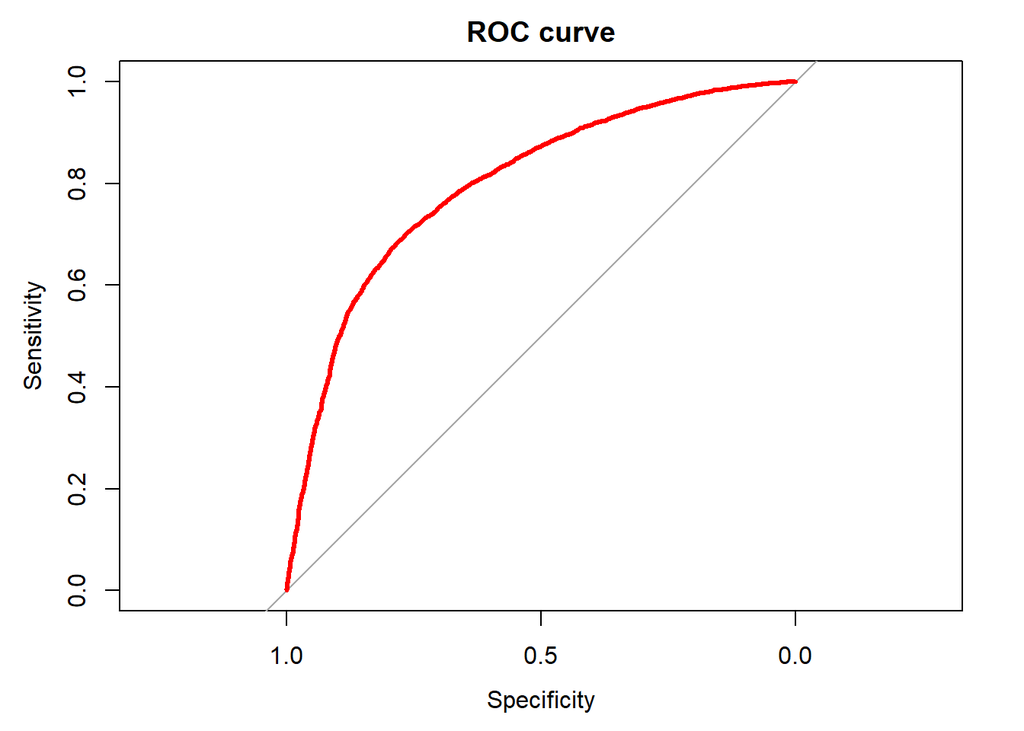

```
## [[1]]
##
## Call:
## roc.default(response = true_val, predictor = probs)
##
## Data: probs in 5788 controls (true_val 0) < 6024 cases (true_val 1).
## Area under the curve: 0.7972
##
## [[2]]
## Area under the curve: 0.7972
```

```r
ROC_AUC(validate_y, pred_prob_keras1)
```

### **ANN: Two Hidden Layer**

##### **Loss Function:**

##### Loss function also remains the same: **binary_crossentropy**

```r
batch_size_grid <- c(64,128)
epochs_grid <- c(40,60)
hid_nod_grid <- c(10,15,19)

ann2_models <- list()
ann2_fits <- list()

p <- 1
for (i in 1:length(batch_size_grid)){
  for (j in 1:length(epochs_grid)){
   for (k in 1:length(hid_nod_grid)){
      keras2_model <- keras_model_sequential()
      keras2_model %>%
        layer_dense(units = 19, kernel_initializer = "uniform", activation = "relu", input_shape
                    = ncol(train_x)) %>%
        layer_dropout(rate = 0.2) %>%
        layer_dense(units = hid_nod_grid[k], kernel_initializer = "uniform", activation =
                      "relu") %>%
        layer_dropout(rate = 0.1) %>%
        layer_dense(units = 1, kernel_initializer = "uniform", activation = "sigmoid") %>%
        compile(optimizer = "adam", loss = "binary_crossentropy", metrics = c("accuracy"))

      keras2_fit <- fit(object = keras2_model, x = as.matrix(train_x), y = train_y, batch_size =
                          batch_size_grid[i], epochs = epochs_grid[j], validation_split = 0.25,
                          verbose = F)
      ann2_models[[p]] <- keras2_model
      ann2_fits[[p]] <- keras2_fit
      p <- p + 1
    }
  }
}
```

##### **Finding the Best Model:**

##### Again using the **average validation accuracy** over all epochs as metric to select best model.

```r
avg_acc <- c()
for (i in 1:length(ann2_models)){
  valacc <- ann2_fits[[i]]$metrics$val_accuracy
  avg_acc[i] <- sum(valacc)/length(valacc)
}
best_model_Index <- which.max(avg_acc)
keras2_best_model <- ann2_models[best_model_Index][[1]]
keras2_best_fit <- ann2_fits[best_model_Index][[1]]

paste0("Batch Size for best model is: ", keras2_best_fit$params$batch_size)
```

```
## [1] "Batch Size for best model is: 128"
```

```r
paste0("No. Epochs for best model is: ", keras2_best_fit$params$epochs)
```

```
## [1] "No. Epochs for best model is: 60"
```

##### Plotting the fitted model over the training dataset. This plots gives us the comparison between training accuracy/loss and validation accuracy/loss. If the difference between training and validation accuracy is increasing that means the model is getting overfitted.

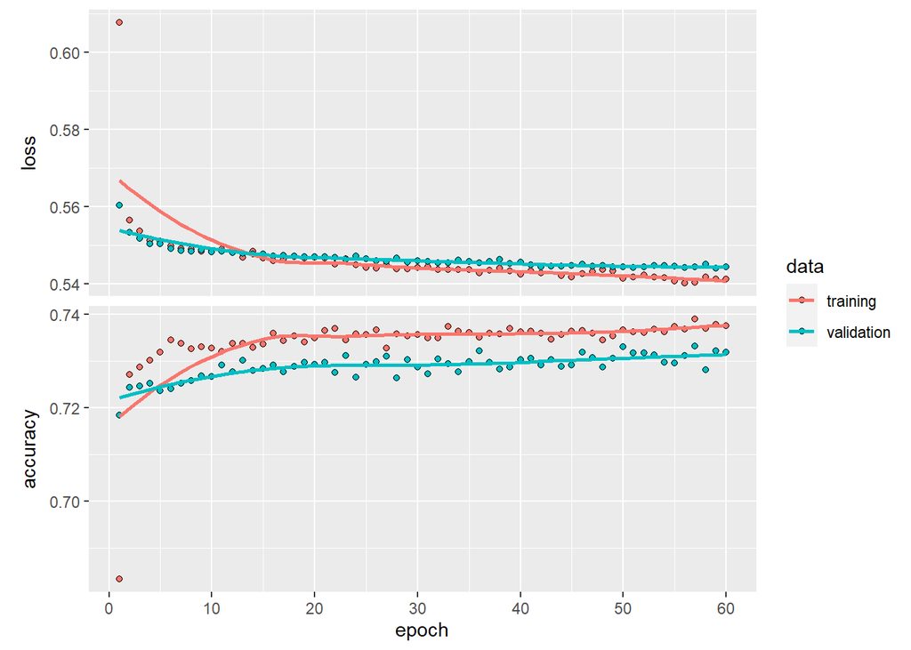

```r
plot(keras2_best_fit)
```

##### **Predictions:**

##### Now, making prediction on the validation data using the best model. Predicting the classes as well as the probabilities for the instances.

```r
pred_class_keras2 <- predict_classes(object = keras2_best_model, x = as.matrix(validate_x)) %>%
as.vector()
pred_prob_keras2 <- predict_proba(object = keras2_best_model, x = as.matrix(validate_x)) %>%
as.vector()
```

##### **Performance Evaluation Parameters:**

##### Plotting the confusion matrix and calculating **Accuracy, Recall and F1-Score**. Again, F1-Score gives a balanced measure of recall and precision.

```r
estimates_keras2_tbl <- tibble(truth = as.factor(validate_y),estimate =
                                 as.factor(pred_class_keras2),class_prob = pred_prob_keras2)

options(yardstick.event_first = F)
estimates_keras2_tbl %>% conf_mat(truth, estimate)
```

```
##           Truth
## Prediction    0    1
##          0 4396 1759
##          1 1392 4265
```

```r
estimates_keras2_tbl %>% metrics(truth, estimate)
```

```
## # A tibble: 2 x 3
##   .metric  .estimator .estimate
##   <chr>    <chr>          <dbl>
## 1 accuracy binary         0.733
## 2 kap      binary         0.467
```

```r
estimates_keras2_tbl %>% recall(truth, estimate)
```

```
## # A tibble: 1 x 3
##   .metric .estimator .estimate
##   <chr>   <chr>          <dbl>
## 1 recall  binary         0.708
```

```r
estimates_keras2_tbl %>% f_meas(truth, estimate, beta = 1)
```

```
## # A tibble: 1 x 3
##   .metric .estimator .estimate
##   <chr>   <chr>          <dbl>
## 1 f_meas  binary         0.730
```

##### **ROC and AUC:**

##### Plotting the ROC curve and calculating the area under curve.

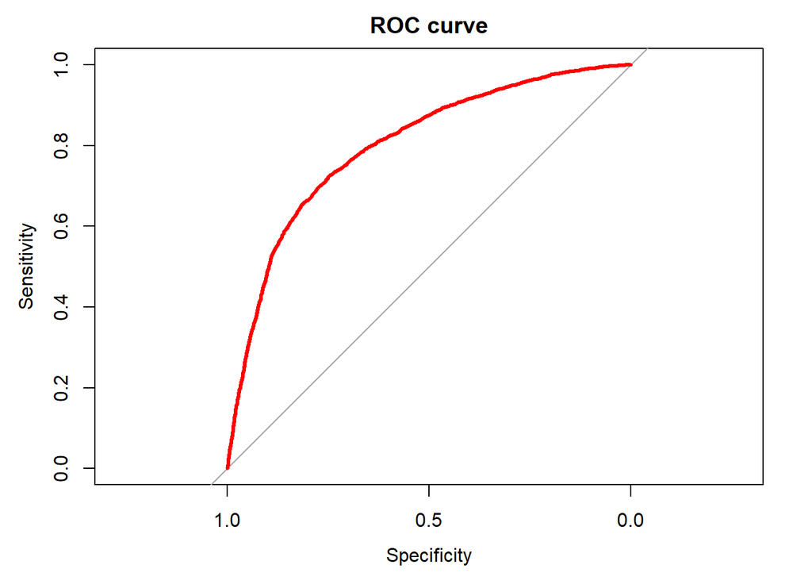

```
## [[1]]
##
## Call:
## roc.default(response = true_val, predictor = probs)
##
## Data: probs in 5788 controls (true_val 0) < 6024 cases (true_val 1).
## Area under the curve: 0.7991
##
## [[2]]
## Area under the curve: 0.7991
```

```r
ROC_AUC(validate_y, pred_prob_keras2)
```

### **ANN: Three Hidden Layer (Voluntary work for Testing)**

##### **Activation Function:**

##### For output layer, it will be the same **Sigmoid Function**, and all the hidden layers we will be using **‘Relu’** acivation function.

##### **Optimzation:**

##### The optimizer remains the same: **adam**

##### **Loss Function:**

##### Loss function also remains the same: **binary_crossentropy**

```r
keras3_model <- keras_model_sequential()
keras3_model %>%
  layer_dense(units = 19, kernel_initializer = "uniform", activation = "relu", input_shape =
                ncol(train_x)) %>%
  layer_dropout(rate = 0.3) %>%
  layer_dense(units = 10, kernel_initializer = "uniform", activation = "relu") %>%
  layer_dropout(rate = 0.2) %>%
  layer_dense(units = 15, kernel_initializer = "uniform", activation = "relu") %>%
  layer_dropout(rate = 0.3) %>%
  layer_dense(units = 1, kernel_initializer = "uniform", activation = "sigmoid") %>%
  compile(optimizer = "adam", loss = "binary_crossentropy", metrics = c("accuracy"))

keras3_fit <- fit(object = keras3_model, x = as.matrix(train_x), y = train_y, batch_size = 64,
                epochs = 100, validation_split = 0.25, verbose = F)
```

##### **Performance Evaluation:**

##### We will be checking the performance of ANN3 model on the validation data.

##### **Results Interpretation:**

##### So, we observe that for this dataset, even if we add a third hidden layer, it does not make any significant changes to the output results. We can infer that 2 hidden layers are enough to make the required combination of values and weights to generate the output. I believe that only 1 hidden layer is enough to improve the accuracy and recall values for this dataset, because we did not see any significant increase in performance after adding second hidden layer as well.

```r
pred_class_keras3 <- predict_classes(object = keras3_model, x = as.matrix(validate_x)) %>%
as.vector()
estimates_keras3_tbl <- tibble(truth = as.factor(validate_y),estimate =
                                 as.factor(pred_class_keras3))
options(yardstick.event_first = F)
estimates_keras3_tbl %>% metrics(truth, estimate)
```

```
## # A tibble: 2 x 3
##   .metric  .estimator .estimate
##   <chr>    <chr>          <dbl>
## 1 accuracy binary         0.732
## 2 kap      binary         0.465
```

```r
estimates_keras3_tbl %>% recall(truth, estimate)
```

```
## # A tibble: 1 x 3
##   .metric .estimator .estimate
##   <chr>   <chr>          <dbl>
## 1 recall  binary         0.677
```

### **Base Model**

##### First testing the base of decision tree on training data and testing the model on validation data.

```r
colnames(train_dm_train) <- make.names(colnames(train_dm_train))
colnames(train_dm_validate) <- make.names(colnames(train_dm_validate))
dt_base <- train(Disease~., data = train_dm_train, metric = "Accuracy", method = "rpart")
dt_base
```

```
## CART
##
## 35436 samples
##    19 predictor
##     2 classes: '0', '1'
##
## No pre-processing
## Resampling: Bootstrapped (25 reps)
## Summary of sample sizes: 35436, 35436, 35436, 35436, 35436, 35436, ...
## Resampling results across tuning parameters:
##
##   cp           Accuracy   Kappa
##   0.004603257  0.7251720  0.4511570
##   0.010271017  0.7193094  0.4398508
##   0.418148340  0.6311782  0.2565327
##
## Accuracy was used to select the optimal model using the largest value.
## The final value used for the model was cp = 0.004603257.
```

##### __Performance Evaluation:__Checking the performance of model on the validation dataset. Evaluation we’ll be using remains same Accuracy and Recall.

```r
dt_base_predict <- predict(dt_base, newdata = train_dm_validate, type = "raw")
confusionMatrix(dt_base_predict, train_dm_validate$Disease, positive = "1")
```

```
## Confusion Matrix and Statistics
##
##           Reference
## Prediction    0    1
##          0 4517 2046
##          1 1276 3973
##
##                Accuracy : 0.7188
##                  95% CI : (0.7106, 0.7269)
##     No Information Rate : 0.5096
##     P-Value [Acc > NIR] : < 2.2e-16
##
##                   Kappa : 0.4387
##
##  Mcnemar's Test P-Value : < 2.2e-16
##
##             Sensitivity : 0.6601
##             Specificity : 0.7797
##          Pos Pred Value : 0.7569
##          Neg Pred Value : 0.6883
##              Prevalence : 0.5096
##          Detection Rate : 0.3364
##    Detection Prevalence : 0.4444
##       Balanced Accuracy : 0.7199
##
##        'Positive' Class : 1
##
```

### **Decision Tree: Tuned Model**

##### **Model Description:**

##### This model generated a classification tree. The root node contains the variable split that contains highest information gain or lowest GINI index after splitting. All the leaf nodes are assigned to class from target variable.

##### **Strategy:** In this case, we will be pre-prunning the tree and not post-prunning. We will use cross-validation to control the model from getting overfitted over the data. There are multiple hyperparameters in “rpart” method to prune the tree. We will be complexity parameter only to prune the tree as it automatically sets the values for few other hyperparameters.

##### **Hyperparameters:**

##### 1] cp (complexity parameter): This parameter decides if the the tree should be expanded further from the current node. If the cost of expanding the tree is more than complexity parameter, then it stops the tree from increasing further. The cost is calculated using the impurity criteria such as Information Gain (entropy) or GINI Index.

##### 2] minsplit: It is the minimum number of observations required to split a node further.

##### 3] minbucket: It is minimum number of observations required to be there in leaf nodes. Genarally, this number is taken as one third of the minsplit value.

##### 4] maxDepth: We will not specify this hyperparameter, and let the tree grow fully and complexity parameter will take care of the length of the tree.

##### Using the best cp value from above results, we specify few values higher and few lower to check for cp value and finally use for loop to find the optimum values for minsplit and minbucket

```r
tunegrid <- expand.grid(cp = seq(0.001, 0.005, 0.001))

dt_models <- list()
for (minsplit in c(20,30,40)){
  set.seed(73)
  dt_tuned <- train(Disease~., data=train_dm_train, method="rpart",
              tuneGrid=tunegrid, trControl = trainControl(method="cv", number=3),
              control= rpart.control(minsplit = minsplit, minbucket =
              round(minsplit/3)))
  min_splits <- toString(minsplit)
  dt_models[[min_splits]] <- dt_tuned
}
```

##### **Best Model:** Since, we used the for loop, we need to find the best model ourselves and then select the final model out of it.

```r
all_acc <- c()
for (i in 1:length(dt_models)){
  acc_vec <- dt_models[[i]]$results$Accuracy
  all_acc <- c(all_acc, acc_vec)
}


best_dt_Index <- ceiling(which.max(all_acc)/length(acc_vec))
dt_tuned_best <- dt_models[best_dt_Index][[1]]
dt_tuned_best
```

```
## CART
##
## 35436 samples
##    19 predictor
##     2 classes: '0', '1'
##
## No pre-processing
## Resampling: Cross-Validated (3 fold)
## Summary of sample sizes: 23624, 23624, 23624
## Resampling results across tuning parameters:
##
##   cp     Accuracy   Kappa
##   0.001  0.7303307  0.4609833
##   0.002  0.7292019  0.4582899
##   0.003  0.7263800  0.4531318
##   0.004  0.7249407  0.4504451
##   0.005  0.7242635  0.4492007
##
## Accuracy was used to select the optimal model using the largest value.
## The final value used for the model was cp = 0.001.
```

##### Plotting the diagram for the best decision tree model.

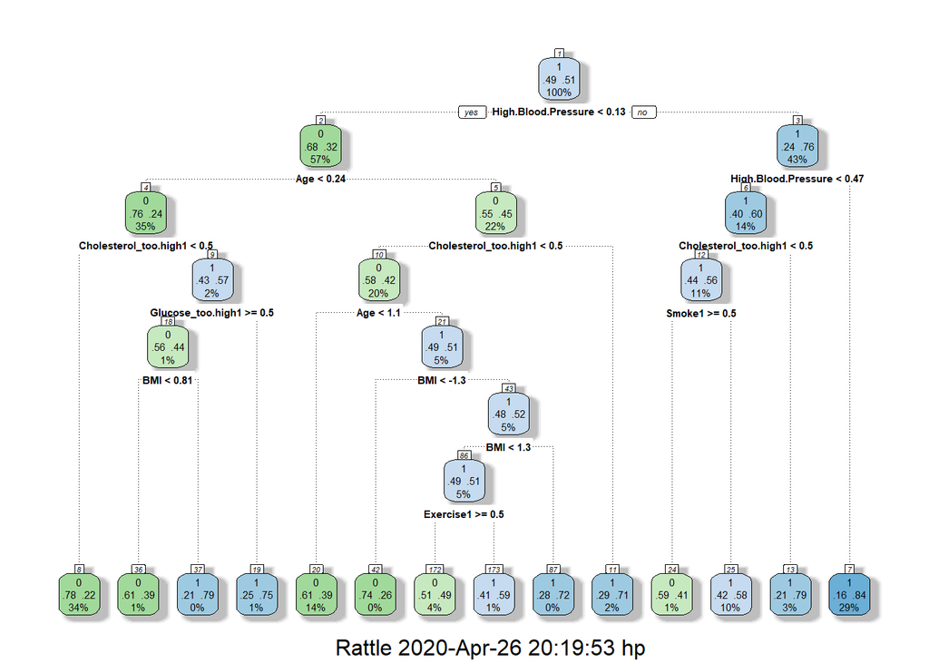

```r
library(rattle)
fancyRpartPlot(dt_tuned_best$finalModel)
```

##### **Preictions:**

##### Testing the model performance on the validation dataset.

```r
dt_tune_predict <- predict(dt_tuned_best, newdata = train_dm_validate, type = "raw")
confusionMatrix(dt_tune_predict, train_dm_validate$Disease, positive = "1")
```

```
## Confusion Matrix and Statistics
##
##           Reference
## Prediction    0    1
##          0 4480 1940
##          1 1313 4079
##
##                Accuracy : 0.7246
##                  95% CI : (0.7164, 0.7326)
##     No Information Rate : 0.5096
##     P-Value [Acc > NIR] : < 2.2e-16
##
##                   Kappa : 0.4501
##
##  Mcnemar's Test P-Value : < 2.2e-16
##
##             Sensitivity : 0.6777
##             Specificity : 0.7733
##          Pos Pred Value : 0.7565
##          Neg Pred Value : 0.6978
##              Prevalence : 0.5096
##          Detection Rate : 0.3453
##    Detection Prevalence : 0.4565
##       Balanced Accuracy : 0.7255
##
##        'Positive' Class : 1
##
```

##### **ROC and AUC:**

##### Plotting the ROC curve and calculating the area under curve.

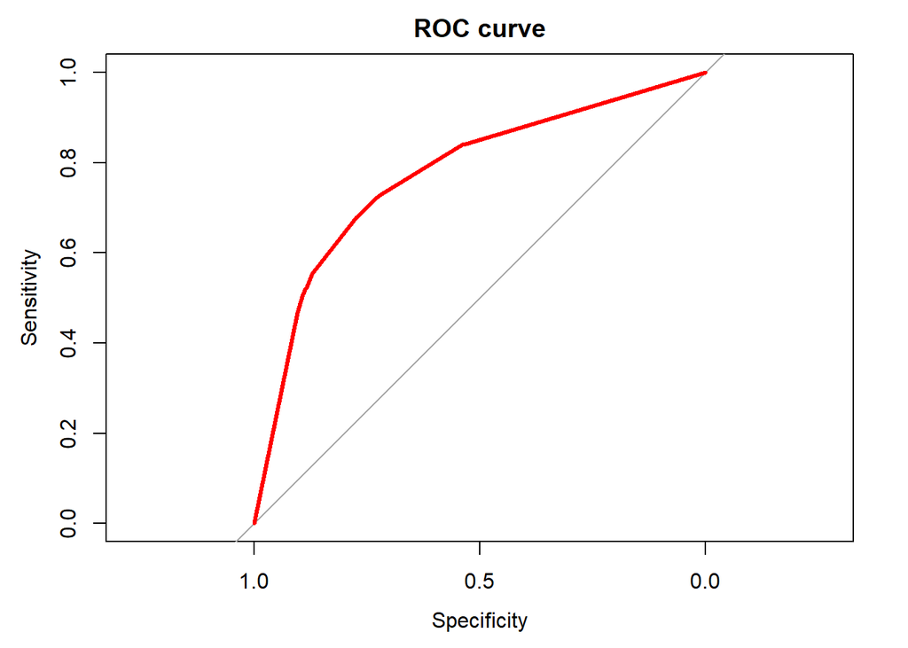

```
## [[1]]
##
## Call:
## roc.default(response = true_val, predictor = probs)
##
## Data: probs in 5793 controls (true_val 0) < 6019 cases (true_val 1).
## Area under the curve: 0.7744
##
## [[2]]
## Area under the curve: 0.7744
```

```r
dt_probs_predict <- predict(dt_tuned_best, newdata = train_dm_validate, type = "prob")
ROC_AUC(train_dm_validate$Disease, dt_probs_predict$`1`)
```

### **Comparing the Variable significane/Importance:**

##### **Gradient Boosting:** For GBM,again High blood pressure, Age and Cholesterol category “too_high” are very imporatnt with respect to fiding out if that person has a disease.

##### **Logistic Regression:** Coefficients tells us the importance of variables: High blood pressure, HTStage2 and Hypertensive have highest coefficient **ignoring the sign** of coefficient. P-value tells us the significane of the coefficient value. We say that Low blood pressure and gender variables are not significant.

```r
#varImp(rf_tuned_best$finalModel)     #Random Forest
#varImp(dt_tuned_best$finalModel)     #Decision Tree
#varImp(gbm_tuned$finalModel)         #Gradient Boosting
#summary(glm_base$finalModel)         #Logistic Regression
```

### **Master Table:** For Comapring Model Performance

##### **Performance Evaluation Method:**

##### Here, we have used cross validation as performance evaluation method, wherever possible.

##### **Primary Performance Metric:**

##### This problem statement asks us to reduce the type 2 error, hence it is very necesaary to optimize recall. Adding to that this is a balanced dataset and for balanced dataset, Accuracy is always a good metric as it covers all the dimensions of predictons. In the last assignment, we saw a pattern that if we tuning for recall decreases accuracy, but tuning for accuracy does not decrease recall by much. Hence, we tuned our models for accuracy and kept our accuracy as our primary performance metric.

```r
knn_predict_trans <- as.factor(as.integer(knn_acc_predict) - 1)
nb_predict_trans <- as.factor(as.integer(nb_tuned_best_predict) - 1)
rf_predict_trans <- as.factor(as.integer(rf_tuned_predict) - 1)
svmnl_predict_trans <- as.factor(as.integer(svm_nl_tuned_predict) - 1)
gbm_predict_trans <- as.factor(as.integer(gbm_tuned_predict) - 1)

knnacc <- confusionMatrix(knn_predict_trans, train_dm_validate$Disease)$overall["Accuracy"]
nbacc <- confusionMatrix(nb_predict_trans, train_dm_validate$Disease)$overall["Accuracy"]
rfacc <- confusionMatrix(rf_predict_trans, train_dm_validate$Disease)$overall["Accuracy"]
svmlacc <- confusionMatrix(svm_predict_trans, train_dm_validate$Disease)$overall["Accuracy"]
svmnlacc <- confusionMatrix(svmnl_predict_trans, train_dm_validate$Disease)$overall["Accuracy"]
gbmacc <- confusionMatrix(gbm_predict_trans, train_dm_validate$Disease)$overall["Accuracy"]
lracc <- confusionMatrix(glmnet_reg_predict, train_dm_validate$Disease)$overall["Accuracy"]
ann0acc <- (estimates_keras0_tbl %>% metrics(truth, estimate))$.estimate[1]
ann1acc <- (estimates_keras1_tbl %>% metrics(truth, estimate))$.estimate[1]
ann2acc <- (estimates_keras2_tbl %>% metrics(truth, estimate))$.estimate[1]
dtacc <- confusionMatrix(dt_tune_predict, train_dm_validate$Disease)$overall["Accuracy"]


Algorithm_Name <- c("K-Nearest Neighbor", "Naive Bayes Classifier", " Random Forest", " SVM Linear", "SVM Non-Linear", "Gradient Boosting", "Logistic Regression", "ANN 0 Hidden Layer", "ANN 1 Hidden Layer", "ANN 2 Hidden Layer", "Decision Tree")

Hyperparameters <- c("K- Number of Neighbors", "Laplace Smoother", "Number of trees(ntree), number of features for each tree(.mtry)", "C - Cost Parameter", "C - Cost Parameter, Lambda - Gaussian Distribution Parameter", "interaction.depth - splits, ntree - trees in gbm, shrinkage - learning rate, n.minobsinnode - min sample in leaf nodes", "lambda - regularization strength, alpha - type of regularization", "batch_size - interval for weight updation, epochs - number of epochs", "batch_size - interval for weight updation, epochs - number of epochs", "batch_size - interval for weight updation, epochs - number of epochs, unit - nodes in 2nd hidden layer", "cp - complexity parameter, minsplit - min sample for splitting, minbucket - min samples in leaf node")

Model_Performance_Accuracy <- c(knnacc, nbacc, rfacc, svmlacc, svmnlacc, gbmacc, lracc, ann0acc, ann1acc, ann2acc, dtacc)

Ballpark_Time_Estimate_minutes <- c(40, 0.1, 120, 180, 240, 30, 0.5, 30, 30, 30, 0.5)

master_table <- data.frame(Algorithm_Name, Hyperparameters, Model_Performance_Accuracy, Ballpark_Time_Estimate_minutes)

master_table <- master_table[order(Model_Performance_Accuracy, decreasing = T),]
master_table
```

```
##            Algorithm_Name
## 10     ANN 2 Hidden Layer
## 6       Gradient Boosting
## 9      ANN 1 Hidden Layer
## 3           Random Forest
## 7     Logistic Regression
## 8      ANN 0 Hidden Layer
## 5          SVM Non-Linear
## 11          Decision Tree
## 1      K-Nearest Neighbor
## 2  Naive Bayes Classifier
## 4              SVM Linear
##                                                                                                           Hyperparameters
## 10                 batch_size - interval for weight updation, epochs - number of epochs, unit - nodes in 2nd hidden layer
## 6  interaction.depth - splits, ntree - trees in gbm, shrinkage - learning rate, n.minobsinnode - min sample in leaf nodes
```

[output cut: 21 more lines]

```r
#View(master_table)
```

##### Transforming test data with respect to the transformed train data to pass it through the various models make our final predictions

```r
test_df <- read.csv('Disease Prediction Testing.csv', stringsAsFactors = F)

#apply(is.na(test_df),2,sum)

#num_test_df <- test_df[sapply(test_df, is.numeric) | sapply(test_df, is.integer)]
#quantiles_test <- c(0.001, 0.002, 0.003, 0.985, 0.99, 0.999, 1)
#out_test_df <- data.frame(row.names = quantiles_test)
#for (i in 1:length(num_test_df)){
#  r <- as.vector(quantile(num_test_df[,i], quantiles_test))
#  out_test_df[,i] <- r
#}
#colnames(out_test_df) <- colnames(num_test_df)
#print(out_test_df)

test_df$Low.Blood.Pressure <- Out_Treat_W(test_df$Low.Blood.Pressure, 0.002, 0.985)
test_df$High.Blood.Pressure <- Out_Treat_W(test_df$High.Blood.Pressure, 0.003, 0.999)

for (i in 1:nrow(test_df)) {
  if (test_df$High.Blood.Pressure[i] >= 180 | test_df$Low.Blood.Pressure[i] >= 120) {
    test_df$BP_Category[i] = "Hypertensive"
  }
  else if (test_df$High.Blood.Pressure[i] >= 140 | test_df$Low.Blood.Pressure[i] >= 90) {
    test_df$BP_Category[i] = "HT_stage2"
  }
  else if (test_df$High.Blood.Pressure[i] >= 130 | test_df$Low.Blood.Pressure[i] >= 80) {
    test_df$BP_Category[i] = "HT_stage1"
  }
  else {
    test_df$BP_Category[i] = "Normal"
  }
}
for (i in 1:nrow(test_df)) {
  test_df$BMI[i] <- (test_df$Weight[i] / ((test_df$Height[i]/100)**2))
}
lr_drop_test <- c('Height', 'Weight')
test_df <- test_df[,-which(names(test_df) %in% lr_drop_test)]

scale_test <- c('Age', 'High.Blood.Pressure', 'Low.Blood.Pressure', 'BMI')
for(i in 1:length(colnames(test_df))){
  if(colnames(test_df)[i] %in% scale_test){
    test_df[,i] <- as.vector(scale(test_df[,i]))
  }
}

dummies_test <- c('Gender','Cholesterol','Glucose', 'BP_Category')
test_df <- dummy_cols(test_df, select_columns = dummies_test)
test_df <- test_df[,-which(names(test_df) %in% dummies_test)]

test_df$ID <- NULL

#Saving the data for ANN
test_df_ann <- test_df
i <- sapply(test_df, is.integer)
test_df[i] <- lapply(test_df[i], as.factor)
test_x <- bake(rec_obj, new_data = test_df_ann)

#prep for decision tree
test_df_dt <- test_df
colnames(test_df_dt) <- make.names(colnames(test_df_dt))
```

##### Now predicting if a person will get the disease or will he/she be safe using actual test data set. Combining all the predictions into a dataframe and exporting the dataframe to a csv file

```r
DT <- predict(dt_tuned_best, newdata = test_df_dt)
LR <- predict(glmnet_reg, newdata = test_df)
ANN0 <- predict_classes(object = keras0_best_model, x = as.matrix(test_x)) %>% as.vector()
ANN1 <- predict_classes(object = keras1_best_model, x = as.matrix(test_x)) %>% as.vector()
ANN2 <- predict_classes(object = keras2_best_model, x = as.matrix(test_x)) %>% as.vector()

HW4_CSV <- data.frame(DT, LR, ANN0, ANN1, ANN2)

View(HW4_CSV)

write.csv(HW4_CSV,"Assignment4.csv", row.names = TRUE)
```

##### Following code is for all the models from previous assignment, it is not required to run them in this file. We are using the predictions from previous assignment. Hence, this cell is just for the reference. Since, we can save the global enviornment variables and load it, we do not need to runs all this models again.

```r
#set.seed(73)
#knn_acc <- train(Disease ~ ., data = train_dm_train, method = "knn",
#                    tuneGrid = data.frame(k = seq(30, 40)),
#                    trControl = trainControl(method = "repeatedcv",
#                                             number = 3, repeats = 3))
#knn_acc_predict <- predict(knn_acc, newdata = train_dm_validate)


#nb_models <- list()
#for  (i in 1:5){
#  nb_tuned <- naiveBayes(Disease ~ ., data = train_dm_train, laplace = i)
#  lap_par <- toString(i)
#   nb_models[[lap_par]] <- nb_tuned
#}
#Accuracies <- c()
#for (i in 1:length(nb_models)){
#  nb_find_best <- predict(nb_models[[i]], train_dm_validate)
#  cm_nb <- confusionMatrix(nb_find_best, train_dm_validate$Disease)
#  Accuracies <- c(Accuracies, cm_nb$overall["Accuracy"])
#}
#nb_tuned_best <- nb_models[[which.max(Accuracies)]]
#nb_tuned_best_predict <- predict(nb_tuned_best, train_dm_validate)


#mt <- round(sqrt(ncol(train_dm_train)))
#control <- trainControl(method="repeatedcv", number=3, repeats=3)
#tunegrid <- expand.grid(.mtry=c((mt-2):(mt)))
#rf_models <- list()
#for (ntree in c(350, 400, 500)) {
#   set.seed(73)
#   rf_tuned <- train(Disease~., data=train_dm_train, method="rf", #metric="Accuracy",tuneGrid=tunegrid,
#                trControl=control, ntree=ntree, verbose = TRUE)
#   num_trees <- toString(ntree)
#   rf_models[[num_trees]] <- rf_tuned
#}
#Accuracy_results <- summary(results)$statistics$Accuracy
#best_model_Index <- ceiling(which.max(Accuracy_results)/ncol(Accuracy_results))
#rf_tuned_best <- rf_models[best_model_Index][[1]]
#rf_tuned_predict <- predict(rf_tuned_best, newdata = train_dm_validate)


#set.seed(73)
#svm_lin_tuned <- train(make.names(Disease) ~ ., data = train_dm_train, method = "svmLinear",
#                 trControl = trainControl(method="repeatedcv", number=3, repeats=3), tuneGrid =                  expand.grid(C = seq(0.5, 0.7, 0.05)), metric="Accuracy")
#svm_lin_tuned_predict <- predict(svm_lin_tuned, newdata = train_dm_validate)


#svm_nl_tuned <- train(Disease ~ ., data = train_dm_train,
#                       tuneGrid = expand.grid(sigma = seq(0.1, 0.3, 0.1), C = seq(0.5, 1.5, #0.5)),
#                       method = "svmRadial", trControl = trainControl(method = "repeatedcv",
#                       number = 3, repeats = 3))
#svm_nl_tuned_predict <- predict(svm_nl_tuned, newdata = train_dm_validate)


#tuneGrid_gbm <- expand.grid(interaction.depth=c(4,6,8), n.trees = c(400,500,600),
#                   shrinkage=c(0.01), n.minobsinnode=c(10))

#trainControl_gbm <- trainControl(method="cv", number=3)
#set.seed(28)
#gbm_tuned <- train(Disease ~ ., data = train_dm_train,
#                       tuneGrid = expand.grid(tuneGrid_gbm), method = "gbm",
#                       trControl = trainControl_gbm, verbose=FALSE, metric="Accuracy")
#gbm_tuned_predict <- predict(gbm_tuned, newdata = train_dm_validate)
```